# 六角形マップによる人口密度の可視化

全国，神奈川県の例

[岩田真一郎](https://shinichiro-iwata.github.io/)（ [神奈川大学経済学部](https://www.econ.kanagawa-u.ac.jp/)）

2024-03-24作成，2025-03-13改定

# 1 目的

- 隣接するデータを六角形ごとにまとめた地図を**六角形（Hexbin）マップ**とよぶ．
  - **Ubar**が開発した地球上の領域を六角形のセルで覆った[H3](https://h3geo.org/)がよく利用される．
  - ここでは，[HDX](https://data.humdata.org/)から提供されているオープンデータの一つである[Kontur](https://www.kontur.io/) Populationを利用．
    - このデータは各H3セルに総人口データが含まれる．各セルは同じ面積だと見なされているため，人口密度として解釈可能．

**パッケージ**：`sf`，`tidyverse`

```r
library(sf)
library(tidyverse)

#sfオブジェクトの編集，簡略化
library(rmapshaper)
```

# 2 Konturデータ

## 2.1 ダウンロード

- 拡張子`.gpkg`ファイル（地理空間データの保存によく利用）で提供されている．
- [HDX Kontur](https://data.humdata.org/organization/kontur?) > 検索欄に`Japan`と入力し，Enterキー > Japan: Population Density for 400m H3 Hexagons
- [kontur_population_JP_20231101.gpkg](https://data.humdata.org/dataset/kontur-population-japan) > DOWNLOAD

### 2.1.1 シェープファイルの読込

- `st_transform()`：JSD2011（`EPSG:6668`）に投影するため．

```r
hexagons <-
  read_sf("kontur_population_JP_20231101.gpkg") %>%
     st_transform("EPSG:6668")

#最初の6行
hexagons %>%
  head()
```

| h3 | population | geom |
| --- | --- | --- |
| 884ec9aeb3fffff | 1 | POLYGON ((142.1747 26.61367… |
| 884ec9acddfffff | 73 | POLYGON ((142.1776 26.62691… |
| 884ec9acd9fffff | 1 | POLYGON ((142.1715 26.62109… |
| 884ec9acd7fffff | 65 | POLYGON ((142.1651 26.63593… |
| 884ec9acd5fffff | 8 | POLYGON ((142.1744 26.63433… |
| 884ec9acd3fffff | 11 | POLYGON ((142.1591 26.63011… |

- `h3`：ポリゴンとして表現されるH3セルのインデックス（**H3Index**とよばれる）．
- `population`：各H3セルに含まれる総人口．

### 2.1.2 可視化

- とりあえず，可視化．
  - 六角形で覆われているが，小さくてわからない．

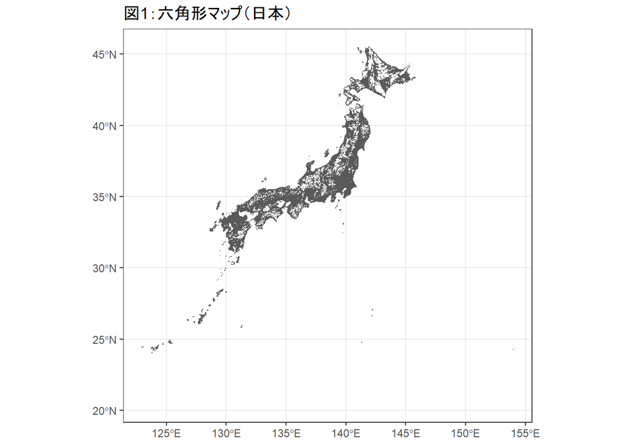

```r
ggplot()+
  geom_sf(data=hexagons)+
  ggtitle("図1：六角形マップ（日本）")+
  theme_bw()
```

**神奈川県周辺**

- 神奈川県周辺だけ可視化．
  - `x`軸（経度）の範囲：`138.8`～`139.8`．
  - `y`軸（緯度）の範囲：`35.1`～`35.8`．

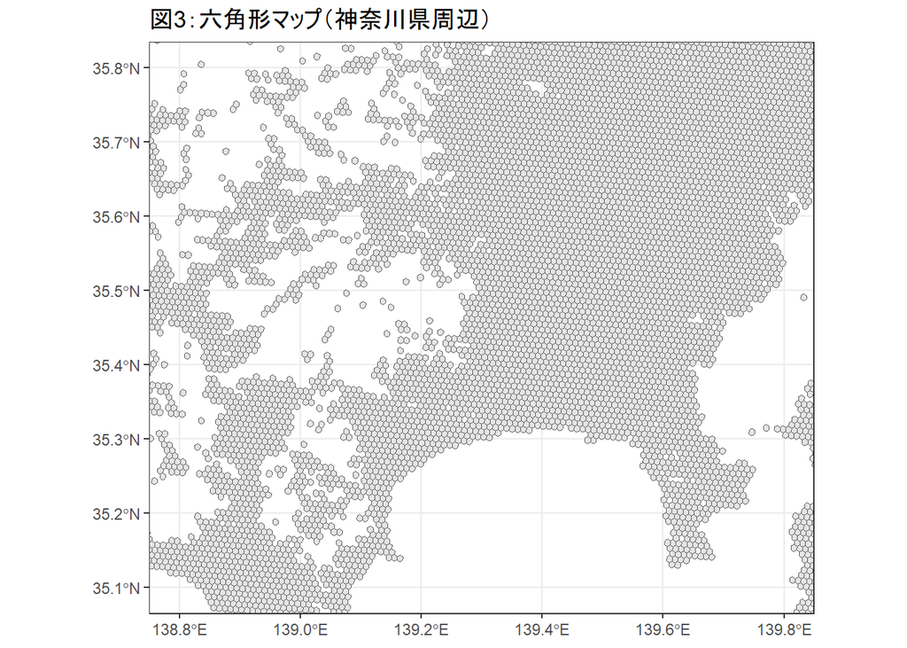

```r
ggplot()+
  geom_sf(data=hexagons)+
  ggtitle("図3：六角形マップ（神奈川県周辺）")+
  coord_sf(xlim= c(138.8, 139.8),
           ylim=c(35.1, 35.8))+
  theme_bw()
```

- 六角形で覆われていることを確認．
  - 今回は人口データのため，陸地の山岳地帯など`population`に値がないポリゴンは`h3`がそもそもデータに含まれず，空白

# 3 人口密度の可視化

- 人口密度1000人/㎢以上（H3セルは約0.74㎢のため740人以上）を`viridis`カラーmako色（`option="G"`）で可視化．
  - 人口密度1000人/㎢未満は`グレー`で表現．
  - 目盛りは常用対数（`log10`）に変換．

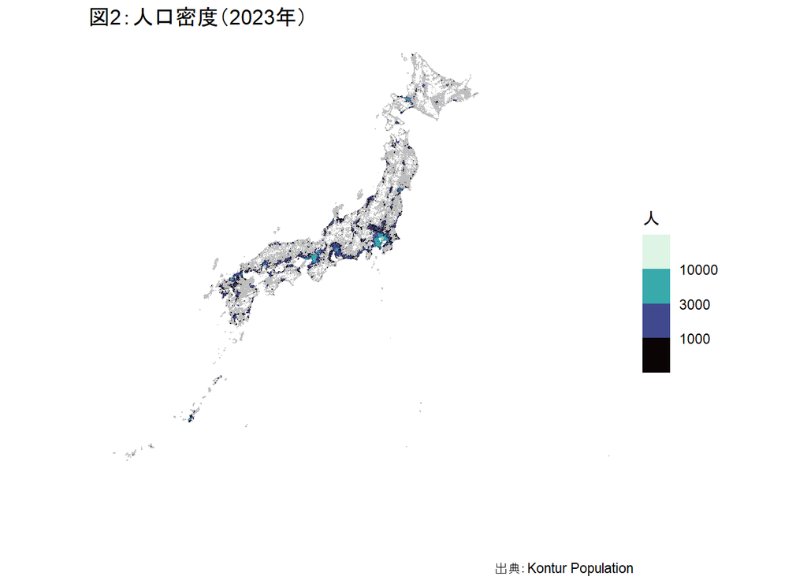

```r
#740人以上の抽出
hexagons_2 <- hexagons %>%
  filter(population>=740)

ggplot()+
  geom_sf(data=hexagons,
          fill="gray", color="gray")+
  geom_sf(data=hexagons_2,
          aes(fill=population,
              color=population))+
  scale_fill_viridis_b(option="G",
                       trans="log10")+
  scale_color_viridis_b(option="G",
                        trans="log10")+
  labs(fill="人", color="人",
       caption="出典：Kontur Population")+
  ggtitle("図2：人口密度（2023年）")+
  theme_void()
```

# 4 神奈川県

## 4.1 行政区域と人口密度の可視化

- 行政区域データを利用して，神奈川県を可視化．
  - [国土数値情報ダウンロードサイト](https://nlftp.mlit.go.jp/ksj/) > 行政区域（ポリゴン） > 神奈川県 > 2024年（令和6年）
  - `rmapshaper`パッケージの`ms_dissolve()`を使用し，市区町村ではなく県単位で境界を統合．`N03_001`列が神奈川県なので，これでまとめる．

```r
Kanagawa_map <-
  read_sf("N03-20240101_14_GML/N03-20240101_14.shp")

#神奈川県を一つのポリンゴンとしてまとめる
Kanagawa_map <- Kanagawa_map %>%
  ms_dissolve(field="N03_001")
```

- 人口を色付けし，神奈川県を可視化．

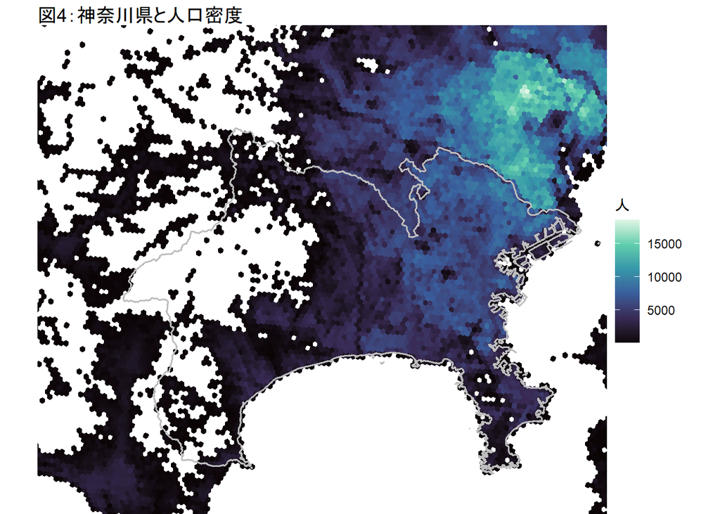

```r
ggplot()+
  geom_sf(data=hexagons,
          aes(fill=population,
              color=population))+
  scale_fill_viridis_c(option="G")+
  scale_color_viridis_c(option="G")+
  geom_sf(data=Kanagawa_map, color="gray",
          linewidth=0.6, fill="NA")+
  labs(fill="人", color="人")+
  ggtitle("図4：神奈川県と人口密度")+
  coord_sf(xlim=c(138.8, 139.8),
           ylim=c(35.1, 35.8))+
  theme_void()
```

## 4.2 神奈川県の人口密度

- 図3は神奈川県周辺も含む⇒神奈川県だけ抽出．
  - `st_intersection()`を用いて，2つのシェープファイル（`hexagons`と`Kanagawa_map`）の重複部分を抽出．
    - `R`コードの詳細は[コミュニティバス路線上の人口密度の可視化](https://shinichiro-iwata.github.io/geospatial-data-visualization/community-bus-visualization.html)参照．

```r
#準備
st_agr(hexagons)="constant"
st_agr(Kanagawa_map)="constant"
```

```r
#重複部分の抽出
Kanagawa_pop <-
  st_intersection(hexagons, Kanagawa_map)
```

- 上のコードで神奈川県だけをくり抜いているため，`coord_sf()`による範囲指定を削除．

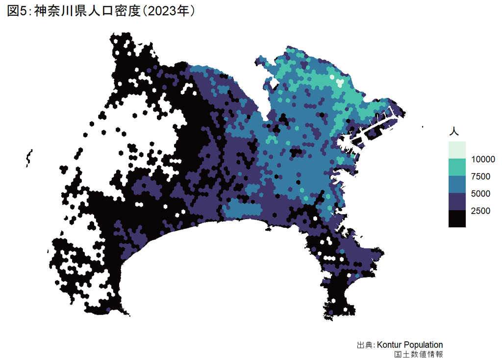

```r
#可視化（完成）
ggplot()+
  geom_sf(data=Kanagawa_pop,
          aes(fill=population,
              color=population))+
  scale_fill_viridis_b(option="G")+
  scale_color_viridis_b(option="G")+
  labs(fill="人", color="人",
       caption="出典：Kontur Population
       国土数値情報")+
  ggtitle("図5：神奈川県人口密度（2023年）")+
  theme_void()
```

# 5 応用

- `rayshader()`を利用すると，図5を3Dマップにすることが可能．ここでは，以下の作業はコンピュータへの負荷が大きいため，示さない．
  - 3Dマップは，例えば[3Dマップによる地価の可視化](https://shinichiro-iwata.github.io/geospatial-data-visualization/3D-visualization.html)参照．
  - kontur_rayshader_tutorialは`render_highquality()`を用いて高品質3Dを作成．（雑感：時間がかかるだけでなく，調整が難しい．）
    - 下記の図は上記サイトの`R`コードを参考に作成．

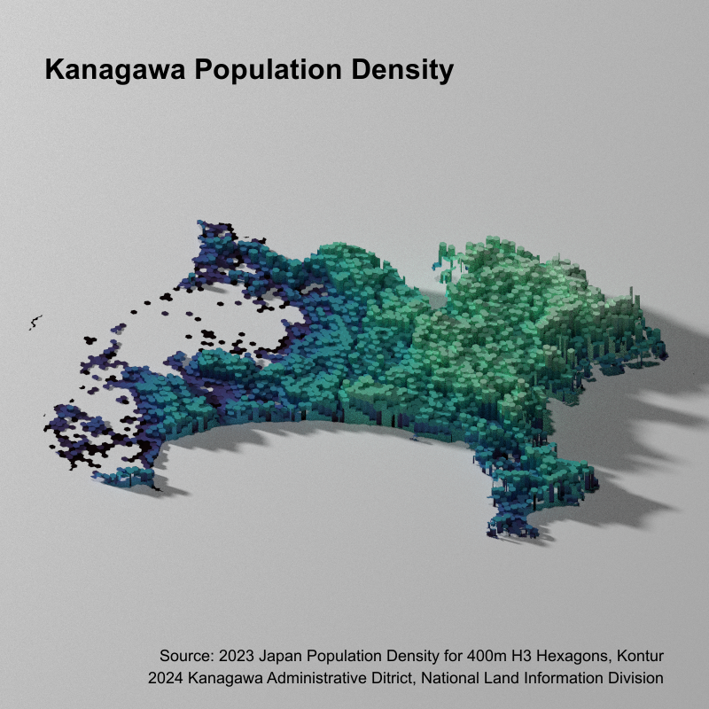

**Rによる地理空間データの可視化**

- チュートリアル[ホーム](https://shinichiro-iwata.github.io/geospatial-data-visualization/)

**アイコン**

[Font Awesome](https://fontawesome.com/) 6.7.2